# DEG on Type 1 Diabetes Associated Bacteria

Pavalya

2025-05-07

```r
#load libraries
library(DESeq2)
```

```r
library(ggplot2)
library(GEOquery)
```

# Step 1: Preparing count data

```r
#read in counts data
counts <- read.delim("type1diabetes_rawcounts.txt", header=TRUE, row.names=1, sep="\t")
head(counts)
```

```
##                 GSM3769106 GSM3769106.1 GSM3769107 GSM3769107.1 GSM3769108
## ENSG00000142611        128          146        101          113         72
## ENSG00000284616          0            0          0            0          0
## ENSG00000157911        175          172        163          117        127
## ENSG00000260972          0            0          0            0          0
## ENSG00000224340          0            0          1            0          0
## ENSG00000229280          0            0          0            0          0
##                 GSM3769108.1 GSM3769111 GSM3769111.1 GSM3769112 GSM3769112.1
## ENSG00000142611           76        150          169         85          105
## ENSG00000284616            0          0            0          0            0
## ENSG00000157911           98        150          184        132          130
## ENSG00000260972            0          0            0          0            0
## ENSG00000224340            0          0            0          0            0
## ENSG00000229280            0          0            0          0            0
##                 GSM3769113 GSM3769113.1 GSM3769114 GSM3769114.1 GSM3769115
## ENSG00000142611         62          103         86           97         69
## ENSG00000284616          0            0          0            0          0
## ENSG00000157911        111          115        134          123        116
## ENSG00000260972          0            0          0            0          0
## ENSG00000224340          0            0          0            0          0
## ENSG00000229280          0            0          0            0          0
##                 GSM3769115.1 GSM3769116 GSM3769116.1 GSM3769117 GSM3769117.1
## ENSG00000142611           60         82          105        106           98
## ENSG00000284616            0          0            0          0            0
## ENSG00000157911           91        107          127        133          145
## ENSG00000260972            0          0            0          0            0
## ENSG00000224340            0          0            0          0            0
## ENSG00000229280            0          0            0          0            0
##                 GSM3769118 GSM3769118.1 GSM3769119 GSM3769119.1 GSM3769120
## ENSG00000142611         77           76         66           81         72
## ENSG00000284616          0            0          0            0          0
## ENSG00000157911        141          129        117          141        142
## ENSG00000260972          0            0          0            0          0
## ENSG00000224340          0            0          0            0          0
## ENSG00000229280          0            0          0            0          0
##                 GSM3769120.1 GSM3769121 GSM3769121.1 GSM3769122 GSM3769122.1
## ENSG00000142611           72        106          116         82           80
## ENSG00000284616            0          0            0          0            0
## ENSG00000157911          145        154          175        135          112
## ENSG00000260972            0          0            0          0            0
```

[output cut: 50 more lines]

```
## ENSG00000229280            0          0            0          0            0
##                 GSM3769145 GSM3769145.1 GSM3769146 GSM3769146.1 GSM3769147
## ENSG00000142611         52           61         66           49         37
## ENSG00000284616          1            0          0            0          0
## ENSG00000157911         74           78         52           67         68
## ENSG00000260972          0            0          0            0          0
## ENSG00000224340          0            0          0            0          0
## ENSG00000229280          0            0          0            0          0
##                 GSM3769147.1
## ENSG00000142611           50
## ENSG00000284616            0
## ENSG00000157911           55
## ENSG00000260972            0
## ENSG00000224340            0
## ENSG00000229280            0
```

```r
# Load the count file (if not already loaded)
counts <- read.delim("type1diabetes_rawcounts.txt", header = TRUE, row.names = 1, sep = "\t", check.names = FALSE)

# Remove ".1", ".2", etc. from column names
cleaned_colnames <- sub("\\.\\d+$", "", colnames(counts))

# View unique sample names
unique(cleaned_colnames)
```

```
##  [1] "GSM3769106" "GSM3769107" "GSM3769108" "GSM3769111" "GSM3769112"
##  [6] "GSM3769113" "GSM3769114" "GSM3769115" "GSM3769116" "GSM3769117"
## [11] "GSM3769118" "GSM3769119" "GSM3769120" "GSM3769121" "GSM3769122"
## [16] "GSM3769123" "GSM3769124" "GSM3769125" "GSM3769126" "GSM3769127"
## [21] "GSM3769128" "GSM3769129" "GSM3769130" "GSM3769131" "GSM3769132"
## [26] "GSM3769133" "GSM3769134" "GSM3769135" "GSM3769136" "GSM3769137"
## [31] "GSM3769138" "GSM3769139" "GSM3769140" "GSM3769141" "GSM3769142"
## [36] "GSM3769143" "GSM3769144" "GSM3769145" "GSM3769146" "GSM3769147"
```

```r
#Collapse technical replicates by summing columns
# Replace colnames with cleaned (replicate-free) names
colnames(counts) <- cleaned_colnames
# Collapse duplicate columns by summing them
collapsed_counts <- as.data.frame(t(rowsum(t(counts), group = colnames(counts))))
#check result
dim(collapsed_counts)
```

```
## [1] 78932    40
```

```r
head(colnames(collapsed_counts))
```

```
## [1] "GSM3769106" "GSM3769107" "GSM3769108" "GSM3769111" "GSM3769112"
## [6] "GSM3769113"
```

```r
#read in sample info
# Obtain metadata
library(tidyverse)
sample_info <- read_csv("SraRunTable.csv", show_col_types = FALSE)
View(sample_info)
```

```r
# Manipulate metadata

library(dplyr)

 metadata_sub <- sample_info %>%
  dplyr::select(
    agent,
    'GEO_Accession (exp)',
    source_name,
    time_point)


View(metadata_sub)
# Step 3.1: Rename GEO accession column for ease of use


metadata_sub <- metadata_sub %>%
  rename_with(~ "accession", .cols = matches("GEO_Accession"))



#Step 4: Match metadata to the collapsed count matrix
# Keep only metadata entries that match the count column names
metadata_filtered <- metadata_sub %>%
  filter(accession %in% colnames(collapsed_counts))

# Reorder rows of metadata to match column order in count matrix
metadata_filtered <- metadata_filtered[match(colnames(collapsed_counts), metadata_filtered$accession), ]

# Check alignment
all(metadata_filtered$accession == colnames(collapsed_counts))  # should return TRUE
```

```
## [1] TRUE
```

```r
# making sure the row names in metadata matches to the columns names in counts data
all(metadata_filtered$accession %in% colnames(collapsed_counts))  # should return TRUE
```

```
## [1] TRUE
```

```r
library(DESeq2)
```

#Step 5: Create DESeq2 dataset

```r
# Create DESeq2 object
dds <- DESeqDataSetFromMatrix(countData = collapsed_counts,
                              colData = metadata_filtered,
                              design = ~ agent)  # or ~ agent + time_point if you want both
```

```
##   Note: levels of factors in the design contain characters other than
##   letters, numbers, '_' and '.'. It is recommended (but not required) to use
##   only letters, numbers, and delimiters '_' or '.', as these are safe characters
##   for column names in R. [This is a message, not a warning or an error]
```

```r
# Clean up agent levels: remove parentheses, replace spaces with underscores
dds$agent <- gsub("\\s+", "_", dds$agent)      # Replace spaces with underscores
dds$agent <- gsub("[()]", "", dds$agent)       # Remove parentheses
dds$agent <- factor(dds$agent)                 # Re-factor the cleaned labels

# Check result
levels(dds$agent)
```

```
## [1] "Bacteroides_dorei_BD"   "Escherichia_coli_EC"    "IL-1B"
## [4] "Ruminococcus_gnavus_RG" "Serum-Free_Control"
```

```r
dds
```

```
## class: DESeqDataSet
## dim: 78932 40
## metadata(1): version
## assays(1): counts
## rownames(78932): ENSG00000142611 ENSG00000284616 ... ENSG00000309831
##   ENSG00000309258
## rowData names(0):
## colnames(40): GSM3769106 GSM3769107 ... GSM3769146 GSM3769147
## colData names(4): agent accession source_name time_point
```

# prefiltering: removing rows with low gene counts

#keeping rows that has 10 reads total

```r
keep <- rowSums(counts(dds)) >=10 # True or false(logical values)

# use the logical values to subset deseq dataset object
dds <- dds[keep,]

dds
```

```
## class: DESeqDataSet
## dim: 32839 40
## metadata(1): version
## assays(1): counts
## rownames(32839): ENSG00000142611 ENSG00000157911 ... ENSG00000298181
##   ENSG00000302039
## rowData names(0):
## colnames(40): GSM3769106 GSM3769107 ... GSM3769146 GSM3769147
## colData names(4): agent accession source_name time_point
```

# set the factor level

```r
#To manually set the reference level:
dds$agent <- relevel(dds$agent, ref = "Serum-Free_Control")
dds$agent
```

```
##  [1] Serum-Free_Control     IL-1B                  Escherichia_coli_EC
##  [4] Serum-Free_Control     IL-1B                  Escherichia_coli_EC
##  [7] Bacteroides_dorei_BD   Bacteroides_dorei_BD   Serum-Free_Control
## [10] Ruminococcus_gnavus_RG Ruminococcus_gnavus_RG Escherichia_coli_EC
## [13] Escherichia_coli_EC    IL-1B                  IL-1B
## [16] Bacteroides_dorei_BD   Bacteroides_dorei_BD   Serum-Free_Control
## [19] Ruminococcus_gnavus_RG Ruminococcus_gnavus_RG Escherichia_coli_EC
## [22] Escherichia_coli_EC    IL-1B                  IL-1B
## [25] Bacteroides_dorei_BD   Escherichia_coli_EC    Ruminococcus_gnavus_RG
## [28] Serum-Free_Control     Bacteroides_dorei_BD   Escherichia_coli_EC
## [31] Ruminococcus_gnavus_RG Bacteroides_dorei_BD   Escherichia_coli_EC
## [34] Ruminococcus_gnavus_RG Serum-Free_Control     Bacteroides_dorei_BD
## [37] Escherichia_coli_EC    Ruminococcus_gnavus_RG IL-1B
## [40] IL-1B
## 5 Levels: Serum-Free_Control Bacteroides_dorei_BD ... Ruminococcus_gnavus_RG
```

# run DESeq

```r
dds <- DESeq(dds)
```

```
##   Note: levels of factors in the design contain characters other than
##   letters, numbers, '_' and '.'. It is recommended (but not required) to use
##   only letters, numbers, and delimiters '_' or '.', as these are safe characters
##   for column names in R. [This is a message, not a warning or an error]
```

```
##   Note: levels of factors in the design contain characters other than
##   letters, numbers, '_' and '.'. It is recommended (but not required) to use
##   only letters, numbers, and delimiters '_' or '.', as these are safe characters
##   for column names in R. [This is a message, not a warning or an error]
```

```
##   Note: levels of factors in the design contain characters other than
##   letters, numbers, '_' and '.'. It is recommended (but not required) to use
##   only letters, numbers, and delimiters '_' or '.', as these are safe characters
##   for column names in R. [This is a message, not a warning or an error]
```

```
## -- replacing outliers and refitting for 29 genes
## -- DESeq argument 'minReplicatesForReplace' = 7
## -- original counts are preserved in counts(dds)
```

```
##   Note: levels of factors in the design contain characters other than
##   letters, numbers, '_' and '.'. It is recommended (but not required) to use
##   only letters, numbers, and delimiters '_' or '.', as these are safe characters
##   for column names in R. [This is a message, not a warning or an error]
```

#To Normalize raw counts for visualization:

```r
vsdata <- vst(dds, blind=FALSE)
```

# Lets again look at the qc of our data

#First lets do PCA plot

```
## using ntop=500 top features by variance
```

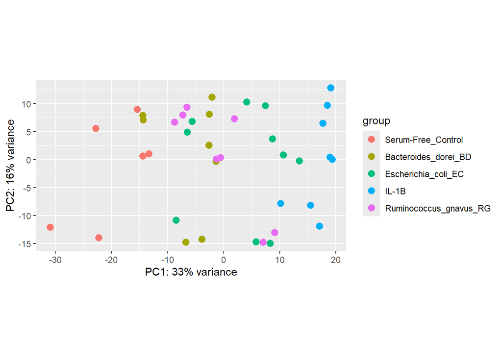

```r
plotPCA(vsdata,intgroup="agent" )
```

```
## using ntop=500 top features by variance
```

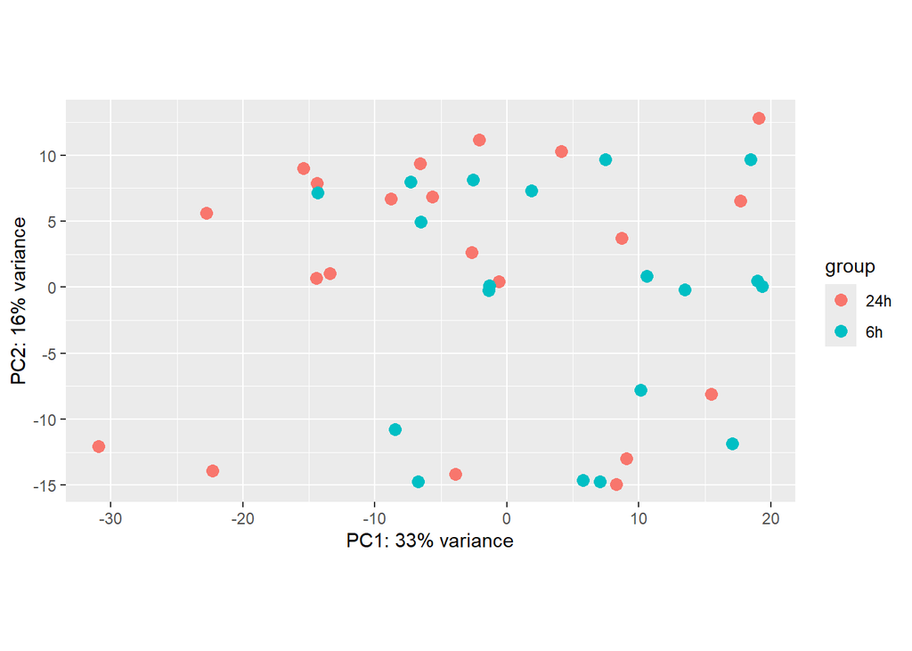

```r
plotPCA(vsdata,intgroup="time_point" )
```

```r
#improve
# Load required libraries
library(DESeq2)
library(ggplot2)

# # STEP 1: Variance Stabilizing Transformation (already done)
# vsdata <- vst(dds, blind = FALSE)
#
# # STEP 2: Select top 1000 most variable genes (optional but improves clarity)
# top_var_genes <- head(order(rowVars(assay(vsdata)), decreasing = TRUE), 1000)
# vsdata_top <- vsdata[top_var_genes, ]
#
# # STEP 3: Get PCA data with sample metadata
# pcaData <- plotPCA(vsdata_top, intgroup = "agent", returnData = TRUE)
# percentVar <- round(100 * attr(pcaData, "percentVar"))
#
# # STEP 4: Custom PCA plot using ggplot2
# ggplot(pcaData, aes(x = PC1, y = PC2, color = agent)) +
#   geom_point(size = 3) +
#   xlab(paste0("PC1: ", percentVar[1], "% variance")) +
#   ylab(paste0("PC2: ", percentVar[2], "% variance")) +
#   ggtitle("PCA of Top 1000 Most Variable Genes") +
#   theme_bw() +
#   theme(
#     legend.position = "right",
#     plot.title = element_text(hjust = 0.5),
#     text = element_text(size = 12)
#   )
#
#
#
#
# pcaData <- plotPCA(vsdata_top, intgroup = c("agent", "time_point"), returnData = TRUE)
#
# ggplot(pcaData, aes(x = PC1, y = PC2, color = agent)) +
#   geom_point(size = 3) +
#   facet_wrap(~ time_point) +
#   theme_bw()
#
#
#


# ggplot(pcaData, aes(x = PC1, y = PC2, color = agent)) +
#   geom_point(size = 3, alpha = 0.9) +
#   facet_wrap(~ time_point) +
#   xlab(paste0("PC1: ", percentVar[1], "% variance")) +
#   ylab(paste0("PC2: ", percentVar[2], "% variance")) +
#   ggtitle("PCA by Treatment Agent and Time Point") +
#   theme_bw() +
#   theme(
#     plot.title = element_text(hjust = 0.5, size = 14, face = "bold"),
#     strip.text = element_text(size = 12),
#     axis.text = element_text(size = 10),
#     axis.title = element_text(size = 12),
#     legend.title = element_text(size = 12),
#     legend.text = element_text(size = 10)
#   )


#Make sure vsdata is defined:
vsdata <- vst(dds, blind = FALSE)
# Save output to PNG
png("PCAplot_agents_time.png", width = 1200, height = 1000, res = 200)
# Example with shape for agent and color for time_point
pcaData <- plotPCA(vsdata, intgroup = c("agent", "time_point"), returnData = TRUE)
```

```
## using ntop=500 top features by variance
```

```r
percentVar <- round(100 * attr(pcaData, "percentVar"))

ggplot(pcaData, aes(PC1, PC2, color = time_point, shape = agent)) +
  geom_point(size = 3) +
  xlab(paste0("PC1: ", percentVar[1], "% variance")) +
  ylab(paste0("PC2: ", percentVar[2], "% variance")) +
  ggtitle("PCA: Combined View by Time and Agent") +
  theme_bw()
dev.off()
```

#Volcano Plot: IL-1B vs Serum-Free_Control

```r
# # Run DESeq2 if not already done
# dds <- DESeq(dds)
#
# # Set reference level
# dds$agent <- relevel(dds$agent, ref = "Serum-Free_Control")
#Make sure vsdata is defined:
vsdata <- vst(dds, blind = FALSE)
# Save output to PNG
png("volcanoplot_IL-1B_Serum-Free_Control.png", width = 1200, height = 1000, res = 300)

# Extract results: IL-1B vs Serum-Free_Control
res_IL1B <- results(dds, contrast = c("agent", "IL-1B", "Serum-Free_Control"))

# Remove NA and order by adjusted p-value
res_IL1B <- na.omit(res_IL1B)
res_IL1B$gene <- rownames(res_IL1B)
res_IL1B <- as.data.frame(res_IL1B)  # 🔧 Convert to plain data frame


# Volcano plot
library(ggplot2)
library(dplyr)

res_IL1B <- res_IL1B %>%
  mutate(
    sig = ifelse(padj < 0.05 & abs(log2FoldChange) > 1,
                 ifelse(log2FoldChange > 1, "Up", "Down"),
                 "NS")
  )


ggplot(res_IL1B, aes(x = log2FoldChange, y = -log10(padj), color = sig)) +
  geom_point(alpha = 0.7) +
  scale_color_manual(values = c("Up" = "red", "Down" = "blue", "NS" = "grey")) +
  labs(title = "Volcano Plot: IL-1B vs Control",
       x = "log2 Fold Change",
       y = "-log10 Adjusted P-value") +
  theme_minimal()
dev.off()
```

#Volcano Plot: Bacteroides_dorei_BD vs Serum-Free_Control

```r
#Make sure vsdata is defined:
vsdata <- vst(dds, blind = FALSE)
# Save output to PNG
png("volcanoplot_Bacteroides_dorei_BD_Serum-Free_Control.png", width = 1200, height = 1000, res = 300)
# Extract results: Bacteroides dorei vs Control
res_BD <- results(dds, contrast = c("agent", "Bacteroides_dorei_BD", "Serum-Free_Control"))

# Remove NA values
res_BD <- na.omit(res_BD)

# Add gene IDs
res_BD$gene <- rownames(res_BD)

# Mark significance based on adjusted p-value and log2 fold change
res_BD_df <- as.data.frame(res_BD) %>%
  dplyr::mutate(sig = ifelse(padj < 0.05 & abs(log2FoldChange) > 1,
                             ifelse(log2FoldChange > 1, "Up", "Down"),
                             "NS"))

# Volcano plot
library(ggplot2)
ggplot(res_BD_df, aes(x = log2FoldChange, y = -log10(padj), color = sig)) +
  geom_point(size = 1) +
  scale_color_manual(values = c("Up" = "red", "Down" = "blue", "NS" = "grey")) +
  labs(title = "Volcano Plot: Bacteroides dorei vs Control",
       x = "log2 Fold Change", y = "-log10 Adjusted P-value") +
  theme_minimal()
dev.off()
```

These DEGs could include cytokines, chemokines, or other signaling molecules relevant to autoimmunity.

#Heatmap of Top DEGs for All Bacterial Agents vs Control

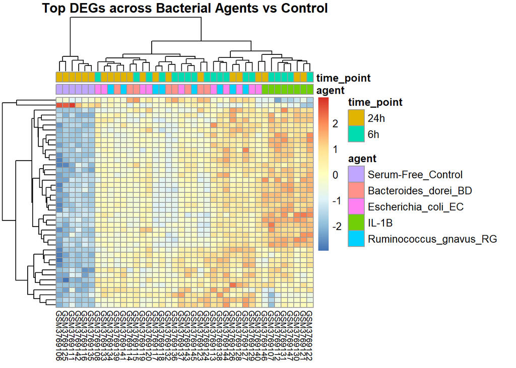

```r
#Make sure vsdata is defined:
vsdata <- vst(dds, blind = FALSE)

# Load required libraries
library(DESeq2)
library(pheatmap)
library(dplyr)

# Save output to PNG
png("Heatmap_Top_DEGs_Across_Agents.png", width = 1200, height = 1000, res = 150)
vsdata <- vst(dds, blind = FALSE)



# Define bacterial agents and control
bacterial_agents <- c("Bacteroides_dorei_BD", "Escherichia_coli_EC", "Ruminococcus_gnavus_RG")
reference <- "Serum-Free_Control"
top_genes_all <- c()

# Extract top genes from each comparison
for (agent in bacterial_agents) {
  res <- results(dds, contrast = c("agent", agent, reference))
  res <- na.omit(res)

  sig_res <- res %>%
    as.data.frame() %>%
    filter(padj < 0.05 & abs(log2FoldChange) > 1) %>%
    arrange(padj)

  top_genes <- rownames(sig_res)[1:min(30, nrow(sig_res))]
  top_genes_all <- unique(c(top_genes_all, top_genes))
}

# Subset VST-normalized expression for top genes
vsdata_sub <- assay(vsdata)[top_genes_all, ]

# Create annotation dataframe
annotation_col <- as.data.frame(colData(vsdata)[, c("agent", "time_point")])

# Plot the heatmap
pheatmap(vsdata_sub,
         annotation_col = annotation_col,
         scale = "row",
         fontsize_row = 6,
         fontsize_col = 8,
         main = "Top DEGs across Bacterial Agents vs Control",
         clustering_distance_rows = "euclidean",
         clustering_distance_cols = "euclidean",
         show_rownames = FALSE)
```

```r
dev.off()
```

# explore results

#save the results

```r
res <- results(dds)
# view the results
res
```

```
## log2 fold change (MLE): agent Ruminococcus gnavus RG vs Serum.Free Control
## Wald test p-value: agent Ruminococcus gnavus RG vs Serum.Free Control
## DataFrame with 32839 rows and 6 columns
##                  baseMean log2FoldChange     lfcSE      stat    pvalue
##                 <numeric>      <numeric> <numeric> <numeric> <numeric>
## ENSG00000142611   164.309     -0.2832589  0.123889 -2.286390 0.0222315
## ENSG00000157911   236.512      0.0368918  0.127691  0.288915 0.7726462
## ENSG00000142655   290.564      0.0861587  0.120832  0.713046 0.4758170
## ENSG00000149527   969.252     -0.8197723  0.394504 -2.077980 0.0377112
## ENSG00000171621   725.281      0.1726173  0.111979  1.541515 0.1231915
## ...                   ...            ...       ...       ...       ...
## ENSG00000298139  2.842131       1.031222  0.635209  1.623439  0.104496
## ENSG00000298153  0.565472      -0.853933  1.179714 -0.723848  0.469159
## ENSG00000298169 30.396124       0.446432  0.403076  1.107562  0.268051
## ENSG00000298181  0.608564       0.695391  1.098512  0.633030  0.526714
## ENSG00000302039  2.340710       0.596627  0.665807  0.896096  0.370201
##                      padj
##                 <numeric>
## ENSG00000142611  0.194879
## ENSG00000157911  0.942853
## ENSG00000142655  0.825324
## ENSG00000149527  0.261615
## ENSG00000171621  0.483560
## ...                   ...
## ENSG00000298139  0.445791
## ENSG00000298153        NA
## ENSG00000298169  0.671289
## ENSG00000298181        NA
## ENSG00000302039  0.756758
```

# logfold2 change calculated in desired factor agent with refernce as serum free control

# All the values here is with respect to Ruminococcus gnavus

#The statistical test used here is wald test # base mean: Average of the normalized counts taken over of all the samples #log2 fold change is the change of the respective gene in the Ruminococcus gnavus comapred to Serum.Free Control. #The positive values are upregulated genes in the Ruminococcus gnavus condition and negative values are downregulated genes in the Ruminococcus gnavus condition. #ifcSE: Provides the standard error estimates of the log2fold change # The stat here are the wald test values for these genes. #p value is for the test statistic for this gene. #padj value are corrected pvalue for multiple testing. #Note: We need to correct the pvalue for multiple testing is because whenever we perform a statsistical test we use a p-value of 0.05, 5% of our DEG’s are not really differentially expressed but they are only due to random chance and there is no real effect. #In our dataset we have around 32839 genes, 5% of 32839 is 1,642 genes, these in our list of DEG’s genes these 1,642 genes are false positives. #To avoid detection of false positives ,these adjp values help

```r
#Summary for the result
summary(res)
```

```
##
## out of 32839 with nonzero total read count
## adjusted p-value < 0.1
## LFC > 0 (up)       : 1007, 3.1%
## LFC < 0 (down)     : 625, 1.9%
## outliers [1]       : 16, 0.049%
## low counts [2]     : 11456, 35%
## (mean count < 2)
## [1] see 'cooksCutoff' argument of ?results
## [2] see 'independentFiltering' argument of ?results
```

```r
#change the padj values
res0.01 <- results(dds, alpha =0.01)
summary(res0.01)
```

```
##
## out of 32839 with nonzero total read count
## adjusted p-value < 0.01
## LFC > 0 (up)       : 434, 1.3%
## LFC < 0 (down)     : 149, 0.45%
## outliers [1]       : 16, 0.049%
## low counts [2]     : 12730, 39%
## (mean count < 3)
## [1] see 'cooksCutoff' argument of ?results
## [2] see 'independentFiltering' argument of ?results
```

#contrasts (more than 2 levels in a factor)

```r
results(dds, contrast=c("agent", "Bacteroides_dorei_BD", "Serum-Free_Control"))
```

```
## log2 fold change (MLE): agent Bacteroides_dorei_BD vs Serum-Free_Control
## Wald test p-value: agent Bacteroides dorei BD vs Serum.Free Control
## DataFrame with 32839 rows and 6 columns
##                  baseMean log2FoldChange     lfcSE       stat     pvalue
##                 <numeric>      <numeric> <numeric>  <numeric>  <numeric>
## ENSG00000142611   164.309    -0.32820330  0.124247 -2.6415353 0.00825312
## ENSG00000157911   236.512     0.01131934  0.127872  0.0885209 0.92946270
## ENSG00000142655   290.564     0.03116565  0.121068  0.2574221 0.79685291
## ENSG00000149527   969.252    -0.69878512  0.394482 -1.7713978 0.07649457
## ENSG00000171621   725.281    -0.00401099  0.112242 -0.0357351 0.97149361
## ...                   ...            ...       ...        ...        ...
## ENSG00000298139  2.842131       1.139354  0.632274   1.801994  0.0715464
## ENSG00000298153  0.565472      -1.190479  1.191131  -0.999453  0.3175753
## ENSG00000298169 30.396124       0.546362  0.402659   1.356886  0.1748173
## ENSG00000298181  0.608564      -0.780486  1.221338  -0.639042  0.5227958
## ENSG00000302039  2.340710       0.373714  0.681893   0.548054  0.5836551
##                      padj
##                 <numeric>
## ENSG00000142611  0.170882
## ENSG00000157911  0.993775
## ENSG00000142655  0.975783
## ENSG00000149527  0.500593
## ENSG00000171621  0.997072
## ...                   ...
## ENSG00000298139        NA
## ENSG00000298153        NA
## ENSG00000298169  0.673762
## ENSG00000298181        NA
## ENSG00000302039        NA
```